# MECH476: Engineering Data Analysis in R

Chapter 6 Homework: Strings, Dates, and Tidying

Tyson Williams

16 October, 2025

# Chapter 6 Homework

For this homework assignment, you will use data from Twitter that include tweets (2011 to 2017) from Colorado senators, which can be downloaded from Canvas. Just FYI—some tweets were cut off before Twitter’s character limit; just work with the data you have. The original data are from [FiveThirtyEight](https://github.com/fivethirtyeight/data/tree/master/twitter-ratio).

When a question asks you to make a plot, remember to set a theme, title, subtitle, labels, colors, etc. It is up to you how to personalize your plots, but put in some effort and think about making the plotting approach consistent throughout the document. For example, you could use the same theme for all plots. I also like to use the subtitle as a place for the main summary for the viewer.

## Question 1: Hashtags

Within a pipeline using the Colorado-only tweet data, select `text` variable and use `stringr::str_extract_all()` with a pattern of `"#(\\d|\\w)+"` to extract all of the hashtags from the tweets. This will return a list with one element. How many hashtags were used by Colorado senators?

```
## # A tibble: 1 × 1
##   total_hashtags
##            <int>
## 1           2569
```

## Question 2: Fires

Colorado is on fire right now and has experienced many wildfires over the years. Let’s examine senators’ tweet activity related to wildfires based on hashtags. Using the character vector of hashtags you extracted in Question 1, search for the hashtags that include “fire” or “wildfire”. How many hashtags included “fire”? How many included “wildfire”?

```
## [1] 46
```

```
## [1] 8
```

## Question 3: Wildfires

Now, let’s look at general tweets concerning wildfires. First, subset the data to a dataframe that includes tweets containing the word “wildfire” and their corresponding timestamp and user. Specifically, (a) select `text`, `date`, and `user` and (b) filter to text strings that include the word “wildfire” using `dplyr::filter()` and `stringr::str_detect()`.

```
## # A tibble: 6 × 3
##   text                                                          created_at user
##   <chr>                                                         <chr>      <chr>
## 1 "Intro'd bill to help #wildfire recovery &amp; prevention ef… 10/6/17 1… SenB…
## 2 "Tune in to watch @USDA @forestservice briefing on fixing #w… 9/26/17 1… SenB…
## 3 "As #opioid addiction rips through Colorado &amp; the countr… 7/5/17 19… SenB…
## 4 "Our thoughts and sympathies are with all of the families af… 7/12/16 2… SenB…
## 5 "Glad to see our wildfire mitigation provision, the Good Nei… 8/6/15 22… SenB…
## 6 "#TBT to speaking with the brave firefighters from @forestse… 6/11/15 2… SenB…
```

## Question 4: Senators

Which Colorado senator tweets more about wildfires?

```
## # A tibble: 2 × 2
##   user           count
##   <chr>          <int>
## 1 SenBennetCO       22
## 2 SenCoryGardner    17
```

## Question 5: Timing

Using the same `wildfires` dataframe, create a summary table that shows the number of tweets containing the word “wildfire” by year (2011-2017). Which year has the most tweets about wildfires? Why might this be the case? (Hint: Think about what happened in the previous year.)

```
## # A tibble: 7 × 2
##    year tweet_count
##   <dbl>       <int>
## 1  2011           2
## 2  2012           4
## 3  2013          16
## 4  2014           1
## 5  2015           8
## 6  2016           5
## 7  2017           3
```

## Question 6: Monthly tweets

Create a bar chart that answers the question: Are Colorado senators more active at a certain time of year? Hints: Convert `month` to a factor. Fill by `user`.

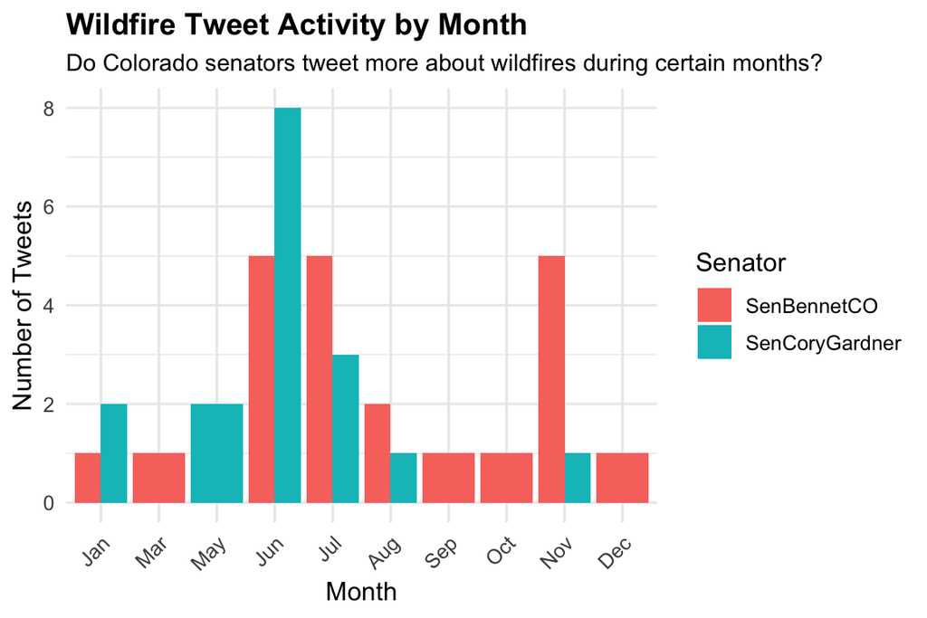

## Question 7: Hourly tweets

Create a histogram of tweets by hour of day to visualize when our senators are tweeting.

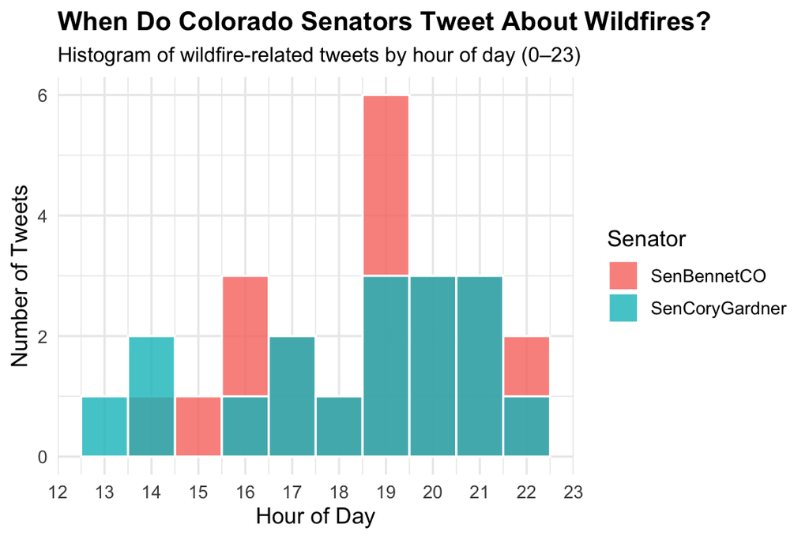

# Appendix

```r
# set global options for figures, code, warnings, and messages
knitr::opts_chunk$set(fig.width=6, fig.height=4, fig.path="../figs/",
                      echo=FALSE, warning=FALSE, message=FALSE)

library(dplyr)
library(stringr)
library(readr)
library(tidyr)
library(lubridate)
library(tidyverse)
# wildfire hashtag list
senators <- read_csv("senators.csv")

senators %>%
  filter(state == "CO") %>%
  select(text) %>%
  mutate(hashtags = str_extract_all(text, "#(\\d|\\w)+")) %>%
  summarise(total_hashtags = sum(lengths(hashtags)))
hashtags_fire <- senators %>%
  filter(state == "CO") %>%
  select(text) %>%
  mutate(hashtags = str_extract_all(text, "#(\\d|\\w)+")) %>%
  unnest_longer(hashtags) %>%
  mutate(hashtags = tolower(hashtags))


fire_count <- hashtags_fire %>%
  filter(str_detect(hashtags, "fire")) %>%
  nrow()

wildfire_count <- hashtags_fire %>%
  filter(str_detect(hashtags, "wildfire")) %>%
  nrow()

fire_count
wildfire_count
wildfire_tweets <- senators %>%
  dplyr::filter(state == "CO") %>%
  dplyr::select(text, created_at, user) %>%
  dplyr::filter(stringr::str_detect(stringr::str_to_lower(text), "wildfire"))

# View the first few results
head(wildfire_tweets)
# number of wildfire tweets by senator
wildfire_counts <- wildfire_tweets %>%
  group_by(user) %>%
  summarise(count = n(), .groups = "drop") %>%
  arrange(desc(count))

wildfire_counts
wildfire_by_year <- wildfire_tweets %>%
  mutate(
    # parse to datetime, flexible to handle odd formats
    created_at = parse_date_time(created_at,
                                 orders = c("Ymd HMS", "Y-m-d H:M:S", "mdy HMS", "mdy HM", "mdy"))
  ) %>%
  mutate(year = year(created_at)) %>%
  filter(year >= 2011 & year <= 2017) %>%
  group_by(year) %>%
  summarise(tweet_count = n(), .groups = "drop") %>%
  arrange(year)

wildfire_by_year
# create plot of tweets by month and user
wildfire_month_activity <- wildfire_tweets %>%
  mutate(
    # safely parse timestamp
    created_at = parse_date_time(created_at,
                                 orders = c("Ymd HMS", "Y-m-d H:M:S", "mdy HMS", "mdy HM", "mdy")),
    month = month(created_at, label = TRUE, abbr = TRUE)  # get month name as ordered factor
  ) %>%
  group_by(user, month) %>%
  summarise(tweet_count = n(), .groups = "drop")

# Plot: wildfire tweets by month and user
ggplot(wildfire_month_activity,
       aes(x = month, y = tweet_count, fill = user)) +
  geom_col(position = "dodge") +
  labs(
    title = "Wildfire Tweet Activity by Month",
    subtitle = "Do Colorado senators tweet more about wildfires during certain months?",
    x = "Month",
    y = "Number of Tweets",
    fill = "Senator"
  ) +
  theme_minimal(base_size = 12) +
  theme(
    plot.title = element_text(face = "bold", size = 14),
    plot.subtitle = element_text(size = 11),
    axis.text.x = element_text(angle = 45, hjust = 1)
  )
# create plot of cumulative hourly tweets by senator
wildfire_by_hour <- wildfire_tweets %>%
  mutate(
    created_at = parse_date_time(created_at,
                                 orders = c("Ymd HMS", "Y-m-d H:M:S", "mdy HMS", "mdy HM", "mdy")),
    hour = hour(created_at)
  )

# Plot histogram of tweet times
ggplot(wildfire_by_hour, aes(x = hour, fill = user)) +
  geom_histogram(binwidth = 1, color = "white", alpha = 0.8, position = "identity") +
  scale_x_continuous(breaks = 0:23) +
  labs(
    title = "When Do Colorado Senators Tweet About Wildfires?",
    subtitle = "Histogram of wildfire-related tweets by hour of day (0–23)",
    x = "Hour of Day",
    y = "Number of Tweets",
    fill = "Senator"
  ) +
  theme_minimal(base_size = 12) +
  theme(
    plot.title = element_text(face = "bold", size = 14),
    plot.subtitle = element_text(size = 11)
  )
```